# Final Project: Spam Filter Analysis

CSZ

December 7, 2018

## Group Member Info

#### Group Name: CSZ

#### Members:

- Shuoqi Zhang (shuoqiz2)
- Yunan Shi (shi38)
- Chuanqi Chen (chuanqi2)

## Introduction and literature review

#### Data source information:

- Source: created in the late 1990s at Hewlett-Packard Labs, contains 4601 emails.
- Linnk: [spam](https://archive.ics.uci.edu/ml/datasets/spambase)

#### Introduction of the data:

This collection of spam e-mails came from postmaster and individuals who had filed spam while non-spam e-mails came from filed work and personal e-mails. These are useful when constructing a personalized spam filter. There are 58 variables in total, and this spam dataset contains 4601 emails, of which 1813 are considered spam while the remaining are not spam.

#### Scientific goal:

- Constructing Spam filter mainly by SVM, Logistic regression and RandomForest
- Test the performance of KNN, LDA and CART Model
- Identifying the variables that contribute to the classification
- Comparing the quality of Spam filter for each Model, to choose the best classifier
- Tuning the classifier decision rule to make it more sensible for a Spam filter since the harm of Type I error and Type II error are different

### *Import Packages*

```r
library("DataExplorer")
library("e1071")
library("kernlab")
library("caret")
library("class")
library("MASS")
library("tree")
library("randomForest")
library("ggplot2")
library("corrplot")
library("bubbles")
```

## Summary statistics and Data Visualization

Import the data

```r
data("spam")
dim(spam)
```

```
## [1] 4601   58
```

```r
summary(spam$type)
```

```
## nonspam    spam
##    2788    1813
```

Show the average proportion of each Character or Number in the emails of spam and nonspam seperately

```r
nonspam = sapply(spam[spam$type == "nonspam",], as.numeric )
onlyspam = sapply(spam[spam$type == "spam",], as.numeric )
mean_spam = colMeans(onlyspam)
mean_nonspam = colMeans(nonspam)
bubbles(value = mean_spam[1:54], label = colnames(spam)[1:54],
        color = rainbow(54, alpha=NULL)[sample(54)])
```

[interactive chart not shown]

```r
bubbles(value = mean_nonspam[1:54], label = colnames(spam)[1:54],
        color = rainbow(54, alpha=NULL)[sample(54)])
```

[interactive chart not shown]

From the above two graphs, we omit the capital letters, and conclude several apparent statistical conclusions with words, numbers and characters. In a spam email, the proportion of occurence of character like ‘you’, ‘your’,‘will’, ‘free’ ,‘our’ and charExclamation (!) are very high which means emails with these words and character (exclamation) appearance or repeatedly appearance are likely to be spam email. For a non-spam email, frequency of ‘you’, ‘george’, ‘hp’, “hpl’,”re" and “will” is very high. In the same way, the occurrence of these words in emails are also likely categorized the emails as non-spam one. Numbers are not that obvious compared with words.

Correlation Check

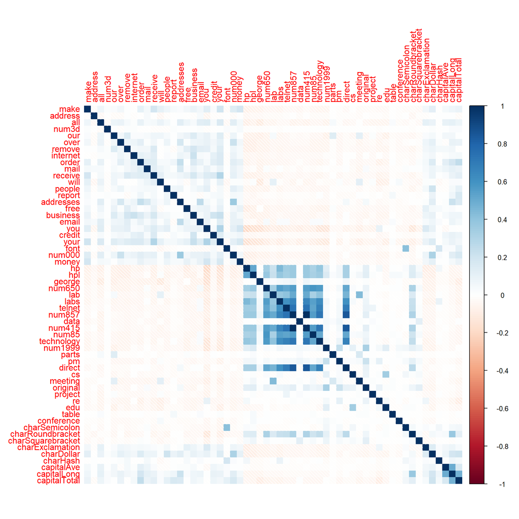

```r
corrplot( cor(spam[,-58]), method = "shade")
```

From the graph we can observe clear positive pattern(blue squares) comparing with negative pattern(red squares). The variables which show in the spam email or non-spam email in the same time will have a positive correlation; variables which show in the spam email and non-spam email in different time will have a negative correlation. Most of the variables have no or lower correlation, Therefore, collinear won’t be a huge problem if we use model of LDA and Logistic Regression to complete our goal.

Permform PCA to visuzlize the whole dataset in low dimension

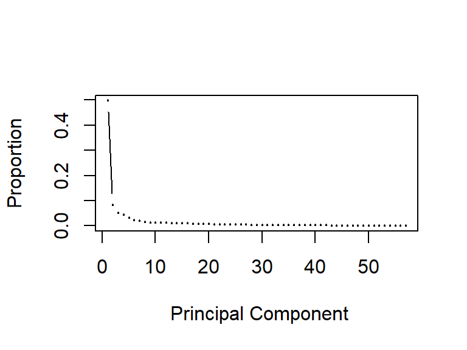

```r
# PCA
pr.out = prcomp(log(spam[,-58]+1))
pr.var = pr.out$sdev^2
pve = pr.var/sum(pr.var)
plot(pve , xlab=" Principal Component",
     ylab="Proportion", type="b", pch = 19, cex = 0.2)
```

From the line chart of *Proportion VS.Principal Component*, the PC1 accounts for about 50%, and pc2 accounts for 8%. Therefore, the 2D PCA visualization catches about 60% information of origninal dataset which is not high enough but still can help us to know the outline and tendency.

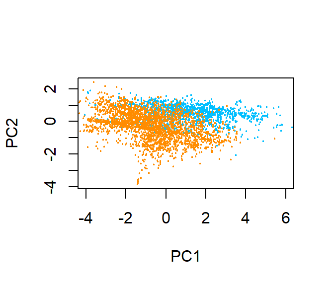

```r
plot(pr.out$x[,1], pr.out$x[,2], col = c("darkorange", "deepskyblue")[spam$type], xlab = "PC1", ylab = "PC2", pch = 19, cex = 0.2, xlim = c(-4, 6))
```

## Proposed Analysis

Our dataset has about 57 variables corresponding to 57 dimentsion which is somehow high dimension. In addition, the each cell value represents the proportion of that words in the total email, therefore the value is a decimal. Therefore, even though each observations is exsits in a very high dimension, they will be crowded or even overlapped in a small space.

For LDA which classify observations into class with the closest centroid in terms of Mahalanobis distance. It woudld perform bad when data points are too crowded. The inverse of $\Sigma$ also may not exist When p is vary large. In addition, using the generalized inverse matrix can easily overfit the data. For KNN classifictaion, which is simply take the mode of K nearest neighbour observations as the prediction for a specific observation. The too close or even same distance between two points would be a disaster for KNN model. Therefore, it would negtively affect the performance of KNN, LDA and other Models.

In the case of this spam data, in order to control the test missclassificaton rate, SVM and RandomForest are my first choices since they are good at handle high-dimension problem. For SVM, it maximize the soft margin which seperate two class with different kernel methods. The SVM classifier only depends on the support vectors. Random Forest is an advanced Classification tree model with bootstrap and randomness. It exaustive search all the variables (dimensions) to maximinze the Node Impurity Reduction. Therefore, even though our p is very large, it would only increate some computation but won’t affect the performance.

Logistic Model is a very classical and useful Surpvised Learning Technique. We are going to first fit this linear model. The model selection techniques can also help us improve the model, by bias-vairance trade off, reduce the size, making it easier to interpret. We can also identify the significant vairalbes which is also one of our Scienctific Goal.

### *Split Data*

Split the original dataset into train data and test data to train the model and then get test missclassifiation rate to compare each models

```r
set.seed(1)
index = sample(nrow(spam), 3000)
spam_trn = spam[index, ]
spam_tst = spam[-index, ]
```

### *Logistic Regression*

Based on the statistics summary and data visualization, we try to find out the most significant variables which may determine the category of email(spam or non-spam). Since logistics regression is a standard approach for binary classification and useful supervised learning technique, we use it as our first testing model.  
Take Logistic Regression as Bayes Classifier Simply classify an observation to the class (spam/nonspam) with the larger probability. In this two case, in order to minimize the misclassification rate, we take the cutoff = 0.5. Perform the logistic model on all the predictors on the training dataset. Then predict the test data to get the confusion table and misclassification rate

```r
logistic_model_full = glm(type ~ . , data = spam_trn, family = "binomial")
p_full = predict(logistic_model_full, newdata = spam_tst, type = "response")
pred_full = ifelse(p_full > 0.5, "spam", "nonspam")
(confusion_table_full = table(pred_full, spam_tst$type))
```

```
##
## pred_full nonspam spam
##   nonspam     929   74
##   spam         47  551
```

```r
(miss_rate_full = mean(pred_full != spam_tst$type))
```

```
## [1] 0.07557776
```

Since we contain all the predictors in the model, it may cause overfitting in our logistics model. Therefore, it is necessary to do a model selection to choose a better model. Apply AIC standard and backward direction to perform the variable selection on the original full model.

```r
# Perform the Variable Selection with backward AIC
logistic_model = step(logistic_model_full, trace = 0)
sort(summary(logistic_model)$coefficients[, "Pr(>|z|)"])[1:5]
```

```
##  (Intercept)         free   charDollar           hp  capitalLong
## 2.936340e-23 5.282440e-10 4.288508e-08 8.849538e-08 1.800423e-07
```

```r
p = predict(logistic_model, newdata = spam_tst, type = "response")
# free, charDollar, hp, capitalLong is the four most significant variable
pred = ifelse(p > 0.5, "spam", "nonspam")
(conftable_logistic = table(pred, spam_tst$type))
```

```
##
## pred      nonspam spam
##   nonspam     934   74
##   spam         42  551
```

```r
(missrate_logistic = mean(pred != spam_tst$type))
```

```
## [1] 0.07245472
```

After variable selection of full model, the misclassification rate lowered from 0.0755778 to 0.0724547 which shows out a better accuracy. The number of variables decreases a lot from 57 to 37 which make it easier for us to interpret. In addition, from the test results, the most significant four variables are free, charDollar, hp, capitalLong. CharDollar is character “$”, capitalLong is the longest length of uninterrupted capital letters; free and hp are two words. Therefore, according to the logistic regression, we can conclude that word free and hp, “$” and the longest length of uninterrupted capital letters might be the important factors to determine an email is spam or not.

### *RandomForest*

Tree-based method is suitble for high-dimension data becaues it exaustive search for every variables and cutoff to find the best pair$x_j, c$. Our dataset has 57 variables in total which represent 57 dimension, which is suspect to high dimension. The tree model partition the feature space into “similar region” by split rule then choose the mode in every region. In addition to make a more robust and stable model, We can improve our tree model to add the technique of *bootstrap* and *randomness*. As rule of thumb, choose $m = seqt(p)$ in the classification case. For another parameter $nodesize$, it controls the bias_variance tradeoff, therefore we use the cross validation to select a reasonable value.

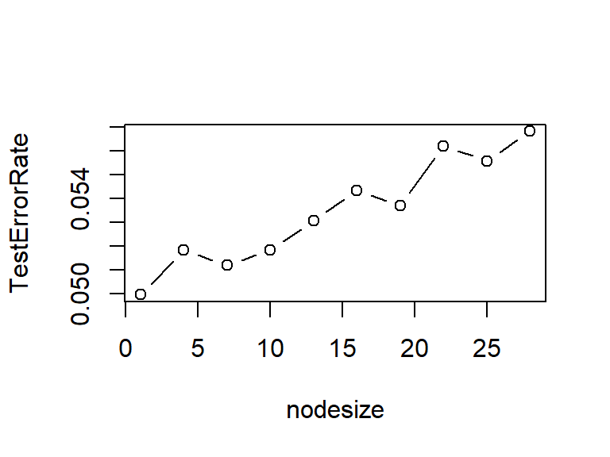

```r
set.seed(1)
mtry = round( sqrt( length(names(spam)) -1 ) )
# Choose Best NodeSize
nodesize = seq(1, 30, by = 3)
TestErrorRate = numeric(length(nodesize))
for( i in 1:length(nodesize) ){
  rf.fit = randomForest(type ~ ., data = spam_trn, ntree = 300, mtry = mtry, nodesize = nodesize[i])
  pred_type = predict(rf.fit, spam_tst ,type = "class")
  TestErrorRate[i] = mean(pred_type != spam_tst$type)
}
plot(nodesize, TestErrorRate, type = "b")
```

```r
(best_nodesize = nodesize[TestErrorRate==min(TestErrorRate)])
```

```
## [1] 1
```

The nodesize stands for the maximum number of observations in the terminal nodes. In this case it is 1. Then we fit the randomForest model with the best paramter made by cross validation

```r
# Fit the RandomForest Model with the best nodesize
rf.spam = randomForest(type ~ ., data = spam_trn, ntree = 300, mtry = mtry, nodesize = best_nodesize,importance = T)
pred_rf = predict(rf.spam, spam_tst,type = "class")
(conftable_RT = table(pred_rf, spam_tst$type))
```

```
##
## pred_rf   nonspam spam
##   nonspam     940   47
##   spam         36  578
```

```r
(missrate_RT = mean(pred_rf != spam_tst$type))
```

```
## [1] 0.0518426
```

```r
# Check the importance of variables.
sort(importance(rf.spam)[, "MeanDecreaseAccuracy"], decreasing = T)[1:5]
```

```
## charExclamation      charDollar          remove      capitalAve
##        38.49454        30.47718        29.48196        28.72698
##              hp
##        28.52775
```

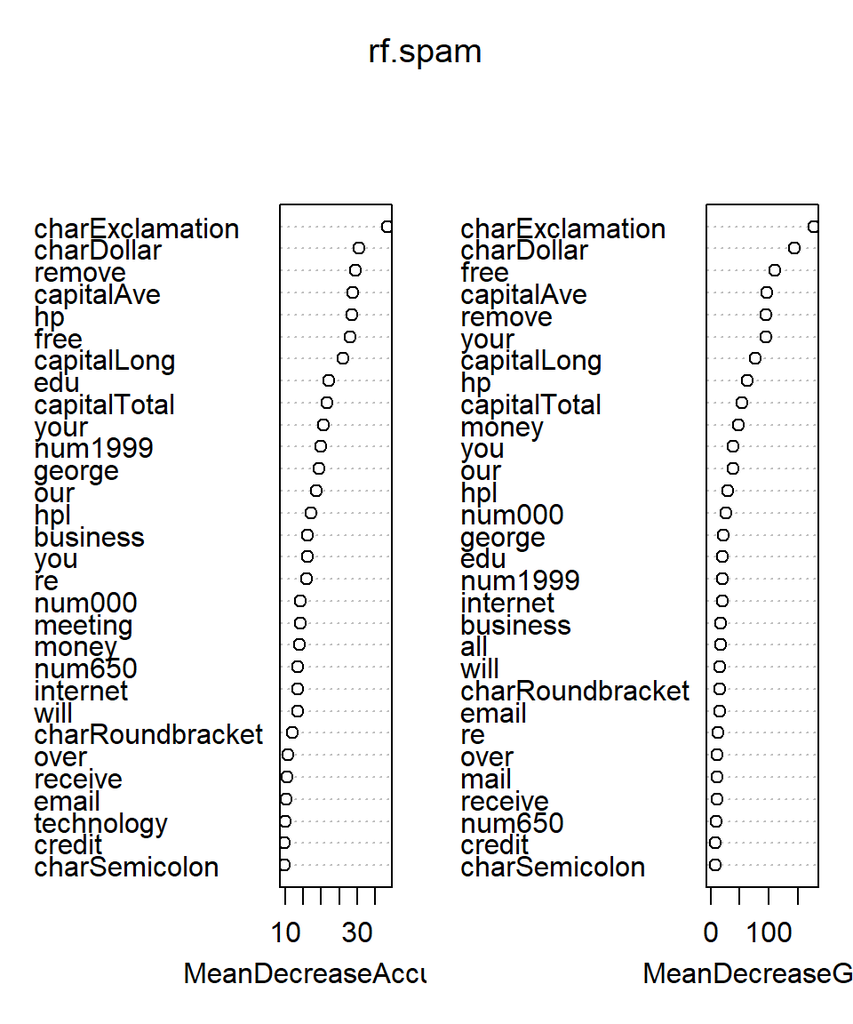

```r
varImpPlot(rf.spam)
```

```r
# charExclamation, charDollar, remove, capitalAve, hp is the most five important variable
```

Higher **Variance Importance** means larger loss of accuracy due to the loss of information on varible $x_j$, hence more important.The graph shows two standards *MeanDecreaseAccuracy* and *MeanDecreaseGini* that mesuare the importance of variables. The first one take the missclassification rate while the second take node impurity Gini as measurement. Our goal is to lower the missclassification rate therefore, choose the first one. From the view of *MeanDecreaseAccuracy* the most five important variables are **charExclamation**, **charDollar**, **remove**, **capitalAve** and **hp** which have an overlap with the most significant variable of Logistic regresison.